# Coursera Practical Machine Learning Course Project

Pablo Ordonez

6/28/2019

#1 Loading data

```r
train <- read.csv("https://d396qusza40orc.cloudfront.net/predmachlearn/pml-training.csv")

test <- read.csv("https://d396qusza40orc.cloudfront.net/predmachlearn/pml-testing.csv")
```

#2 Exploring the data set

```r
dim(train)
```

```
## [1] 19622   160
```

```r
str(train)
```

```
## 'data.frame':    19622 obs. of  160 variables:
##  $ X                       : int  1 2 3 4 5 6 7 8 9 10 ...
##  $ user_name               : Factor w/ 6 levels "adelmo","carlitos",..: 2 2 2 2 2 2 2 2 2 2 ...
##  $ raw_timestamp_part_1    : int  1323084231 1323084231 1323084231 1323084232 1323084232 1323084232 1323084232 1323084232 1323084232 1323084232 ...
##  $ raw_timestamp_part_2    : int  788290 808298 820366 120339 196328 304277 368296 440390 484323 484434 ...
##  $ cvtd_timestamp          : Factor w/ 20 levels "02/12/2011 13:32",..: 9 9 9 9 9 9 9 9 9 9 ...
##  $ new_window              : Factor w/ 2 levels "no","yes": 1 1 1 1 1 1 1 1 1 1 ...
##  $ num_window              : int  11 11 11 12 12 12 12 12 12 12 ...
##  $ roll_belt               : num  1.41 1.41 1.42 1.48 1.48 1.45 1.42 1.42 1.43 1.45 ...
##  $ pitch_belt              : num  8.07 8.07 8.07 8.05 8.07 8.06 8.09 8.13 8.16 8.17 ...
##  $ yaw_belt                : num  -94.4 -94.4 -94.4 -94.4 -94.4 -94.4 -94.4 -94.4 -94.4 -94.4 ...
##  $ total_accel_belt        : int  3 3 3 3 3 3 3 3 3 3 ...
##  $ kurtosis_roll_belt      : Factor w/ 397 levels "","-0.016850",..: 1 1 1 1 1 1 1 1 1 1 ...
##  $ kurtosis_picth_belt     : Factor w/ 317 levels "","-0.021887",..: 1 1 1 1 1 1 1 1 1 1 ...
##  $ kurtosis_yaw_belt       : Factor w/ 2 levels "","#DIV/0!": 1 1 1 1 1 1 1 1 1 1 ...
```

[output cut: 86 more lines]

The train data set contains 160 variables with 19,622 observations.

However several columns are mostly NAs which require further cleaning.

The “classe” variable is the output variable. According to the documentation:

"Six young health participants were asked to perform one set of 10 repetitions of the Unilateral Dumbbell Biceps Curl in five different fashions: exactly according to the specification (Class A), throwing the elbows to the front (Class B), lifting the dumbbell only halfway (Class C), lowering the dumbbell only halfway (Class D) and throwing the hips to the front (Class E).

Class A corresponds to the specified execution of the exercise, while the other 4 classes correspond to common mistakes. Participants were supervised by an experienced weight lifter to make sure the execution complied to the manner they were supposed to simulate. The exercises were performed by six male participants aged between 20-28 years, with little weight lifting experience. We made sure that all participants could easily simulate the mistakes in a safe and controlled manner by using a relatively light dumbbell (1.25kg)."

Read more: http://groupware.les.inf.puc-rio.br/har#dataset#ixzz5rdRbFeQA

#3 Cleaning the data

First we use the nzv or “near zero variance” identification predictors from the Caret package which according to the help guide “diagnoses predictors that have one unique value or predictors that have both the following characteristics: they have very few unique values relative to the numer of samples and the ratio of the frequency of the most common value to the frequency of the second most common value is large”.

```r
nzv <- nzv(train)

train_clean <- train[,-nzv]
test_clean <- test[,-nzv]

dim(train_clean)
```

```
## [1] 19622   100
```

```r
dim(test_clean)
```

```
## [1]  20 100
```

The near-zero-variance reduction dimishes the predictor variables from 160 to 100. However several variables contain a high number of NAs, which we will further clean in the next step.

```r
pp_na <- colSums(is.na(train_clean))/nrow(train_clean)

summary(pp_na)
```

```
##    Min. 1st Qu.  Median    Mean 3rd Qu.    Max.
##  0.0000  0.0000  0.0000  0.4015  0.9793  0.9793
```

```r
#we can clean columns with the proportion of NAs above the 3th quantil

clean_na <- colSums(is.na(train_clean))<0.97*nrow(train_clean)

table(clean_na)
```

```
## clean_na
## FALSE  TRUE
##    41    59
```

```r
#this will remove 41 columns leaving 59 predictors

test_clean <- test_clean[, clean_na]
train_clean <- train_clean[, clean_na]

#further eliminate the first five columns wich contain other ID variables not useful for prediction, leaving 54 predictors

train_clean <- train_clean[, -(1:5)]
test_clean <- test_clean[, -(1:5)]
```

#4 Building the models

We will apply three models to our motion detection data: decision trees, random forest and boosting (gbm). For the later two models we use cross validation with k=2 for time efficiency while the best is to use k=10.

## 4.1 Predicting with trees

```r
set.seed(777)
inTrain <- createDataPartition(train_clean$classe, p = 0.70, list = FALSE)
train_tree <- train_clean[inTrain,]
test_tree <- train_clean[-inTrain,]
modfit_trees <- train(classe ~ ., method = "rpart", data = train_tree)
```

```r
library(rattle)
```

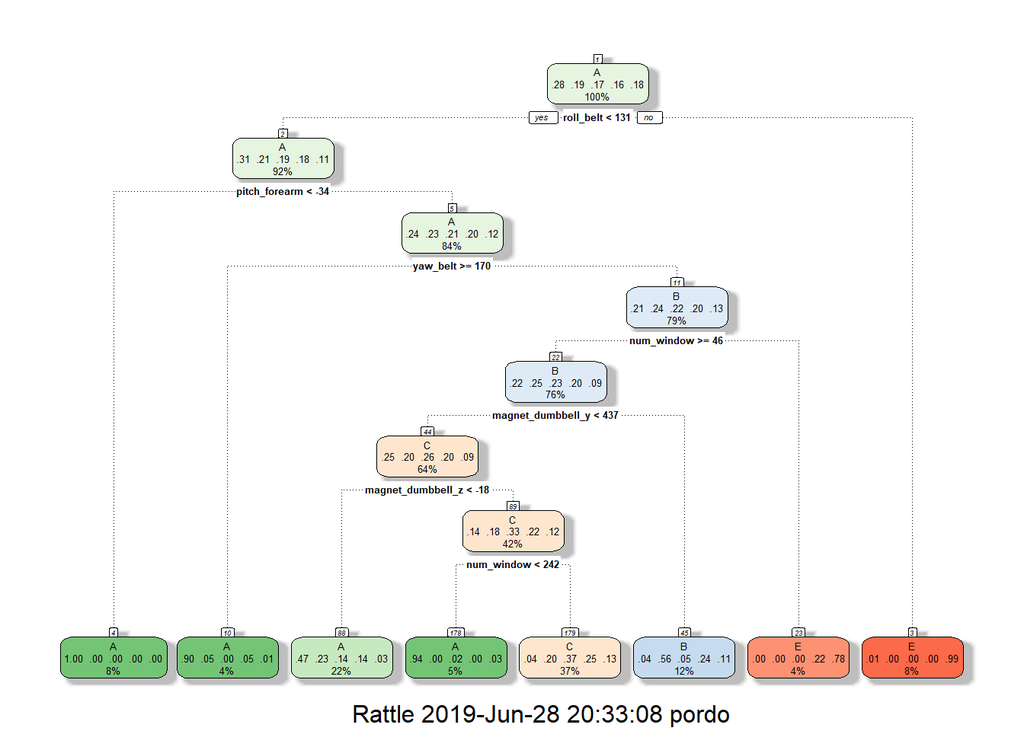

```r
fancyRpartPlot(modfit_trees$finalModel)
```

```r
model_predict_trees <- predict(modfit_trees, newdata = test_tree)

confussion_matrix_trees <- confusionMatrix(test_tree$classe, model_predict_trees)

# Confussion matrix
confussion_matrix_trees$table
```

```
##           Reference
## Prediction    A    B    C    D    E
##          A 1555   28   87    0    4
##          B  302  389  448    0    0
##          C  200   33  793    0    0
##          D  196  180  552    0   36
##          E   51   90  292    0  649
```

```r
# Accuracy
confussion_matrix_trees$overall[1]
```

```
##  Accuracy
## 0.5753611
```

## 4.2 Random Forests

```r
# using cross validation with 2 folds
mytrControl <- trainControl(number=2, method="cv")
modfit_rf <- train(classe ~ ., data = train_tree, method = "rf", trControl=mytrControl,  verbose = FALSE)
model_predict_rf <- predict(modfit_rf, newdata = test_tree)
confussion_matrix_rf <- confusionMatrix(test_tree$classe, model_predict_rf)

# Confussion matrix
confussion_matrix_rf$table
```

```
##           Reference
## Prediction    A    B    C    D    E
##          A 1674    0    0    0    0
##          B    2 1136    1    0    0
##          C    0    2 1024    0    0
##          D    0    0    4  960    0
##          E    0    0    0    2 1080
```

```r
# Accuracy
confussion_matrix_rf$overall[1]
```

```
##  Accuracy
## 0.9981308
```

## 4.3 Boosting

```r
boosting_control <- trainControl(method = "repeatedcv", number = 2, repeats = 1)
modfit_boost <- train(classe ~ ., data = train_tree, method = "gbm", trControl = boosting_control, verbose = FALSE)
model_predict_boost <- predict(modfit_boost, newdata = test_tree)
confussion_matrix_boost <- confusionMatrix(test_tree$classe, model_predict_boost)

# Confussion matrix
confussion_matrix_boost$table
```

```
##           Reference
## Prediction    A    B    C    D    E
##          A 1674    0    0    0    0
##          B    7 1118   11    2    1
##          C    0   15 1009    1    1
##          D    0    9   10  944    1
##          E    0    4    2    8 1068
```

```r
# Accuracy
confussion_matrix_boost$overall[1]
```

```
##  Accuracy
## 0.9877655
```

# 5 Summary and conclusion

Model’s accuracy. The random forest tree has the highest accuracy closely followed by boosting while the decision tree lags behind.

#4. Applying model selection to test data

```r
final <- predict(modfit_rf, newdata = test_clean)
final
```

```
##  [1] B A B A A E D B A A B C B A E E A B B B
## Levels: A B C D E
```